# Propuesta de mejora de tiempo en proceso de gestión y control de inventario, mediante la implementación de WMS para el caso de área de almacén del taller de servicio mecánico integral y electricidad a

# 5 Alcance

Este proyecto propone **mejorar el proceso de gestión de inventario de almacén**, hacer visibles los problemas actuales que de la gestión del almacén y los costos que acarrea, por lo que se tendrá acceso a registros de recepción y despacho durante el periodo 2020 2021, ademas del stock existente. Se intervendrá el espacio físico de la bodega dependiendo de los requerimientos de la mejora.

Con respecto a los trabajadores, se pretende motivar a los colaboradores adoptar métodos que involucren la calidad en el proceso, y que posterior al desarrollo de este proyecto, incentive a mejoras en otras áreas del servicio.

# 6 Estructura

La estructura sería preliminarmente de la siguiente manera:

1. Título.
2. Dedicatoria.
3. Agradecimientos.
4. Índice de contenido.
5. Índice de tablas y figuras.
6. Resumen.
7. Introducción.
8. Objetivos.
9. Objetivo general.
10. Objetivos específicos.
11. Marco teórico.
12. Metodología.
13. Resumen capitular.
14. Desarrollo del trabajo.
15. Conclusiones y/o recomendaciones.
16. Bibliografía.
17. Anexos.

# 7 Carta Gantt

La figura @ref(fig:gantt) presenta la planificación de elaboración del proyecto propuesto.

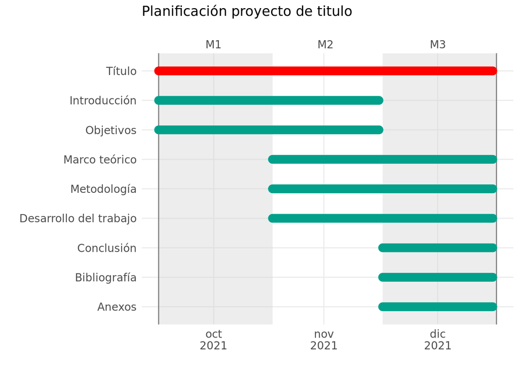

Planificación desarrollo proyecto

# 8 Nombre del(los) memorista(s)

Nombre: Felipe Kiefer

Rut: 17.414.046-4

Firma

## 8.1 Profesor Guía

Nombre:

Rut:

Firma

## 8.2 Malla Curricular

Malla año 2010

# Referencias

Heizer, J., & Render, B. (2009). *Principios de administración de operaciones* (7.ª ed.). Pearson Educación.

Salas, H. G. (2009). *Inventarios: manejo y control*. Ecoe Ediciones.

V, M. G. (2021). Parque de autos se acelera y rozará los 5,5 millones de unidades este año. *El Mercurio*, B2.